# GHG Emissions

## Questions

- How are UK emissions changing?
  - Overall trends
  - Industries and sectors contributing the most to emissions
  - Industries and sectors reducing emissions the quickest and the slowest
- How might emissions change over the next 5 years?
- What are the implications of this for the UK government?

## How are UK emissions changing?

### Data

Data are taken from the ONS’ Atmospheric Emissions dataset. The dataset describes greenhouse gas (GHG) emissions by industry and gas between 1990 and 2021. Carbon dioxide, methane, nitrous oxide, hydro-fluorocarbons, nitrogen trifuoride and sulphur hexafluoride comprise GHGs. The current, rather than provisional, edition of the dataset is used.

Prior to analysis, the tables describing GHG totals were tidied to remove superfluous rows and columns and throughout the analysis, data are queried, reshaped and used to calculate statistics to investigate changes in GHG emissions.

### Overall trends

- GHG emissions are trending downwards with a 40.4% reduction in the mass of air emission per annum in thousand tonnes of C02 equivalent
- GHG emissions in 2021 are 340’158 thousand tonnes of CO2e lower than in 1990

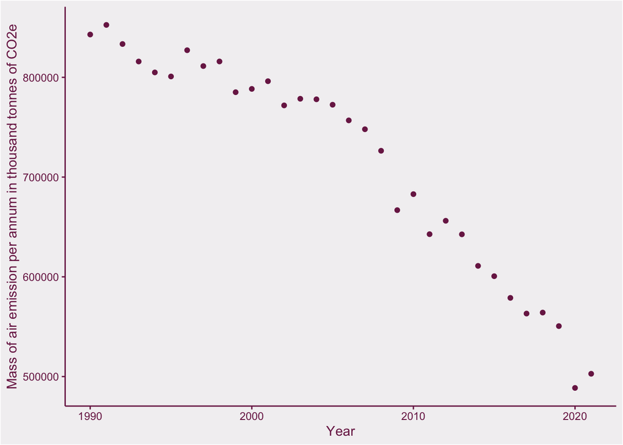

### Industries

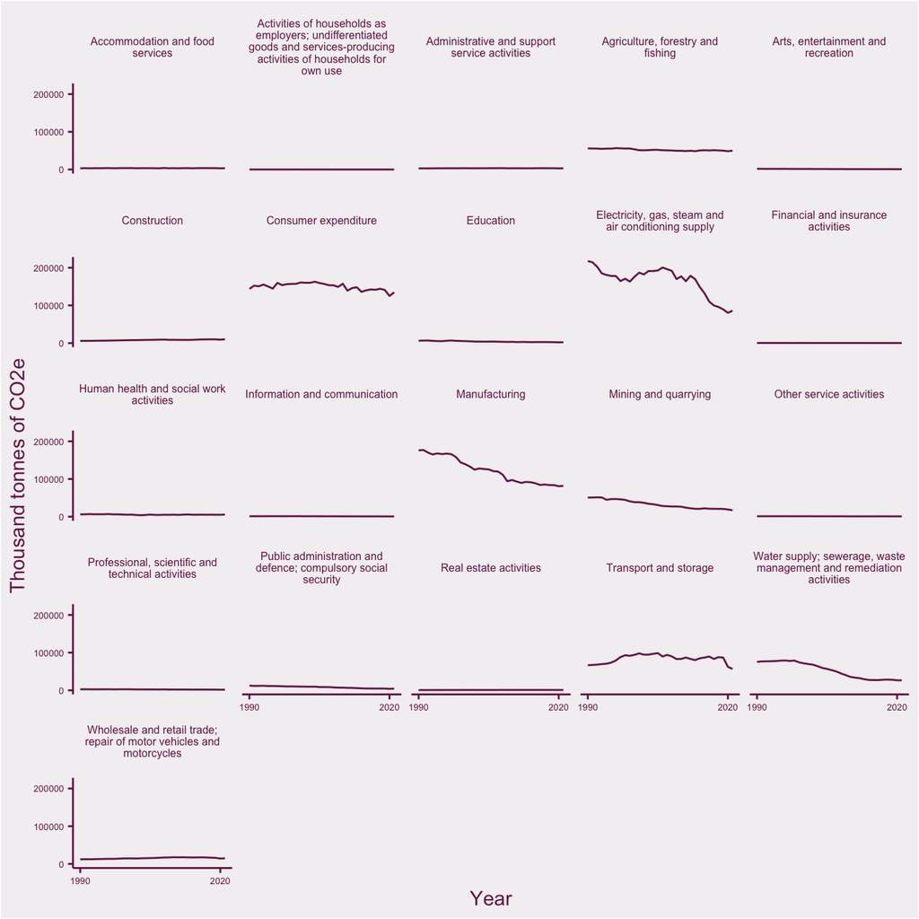

Industries contributing the most to emissions:

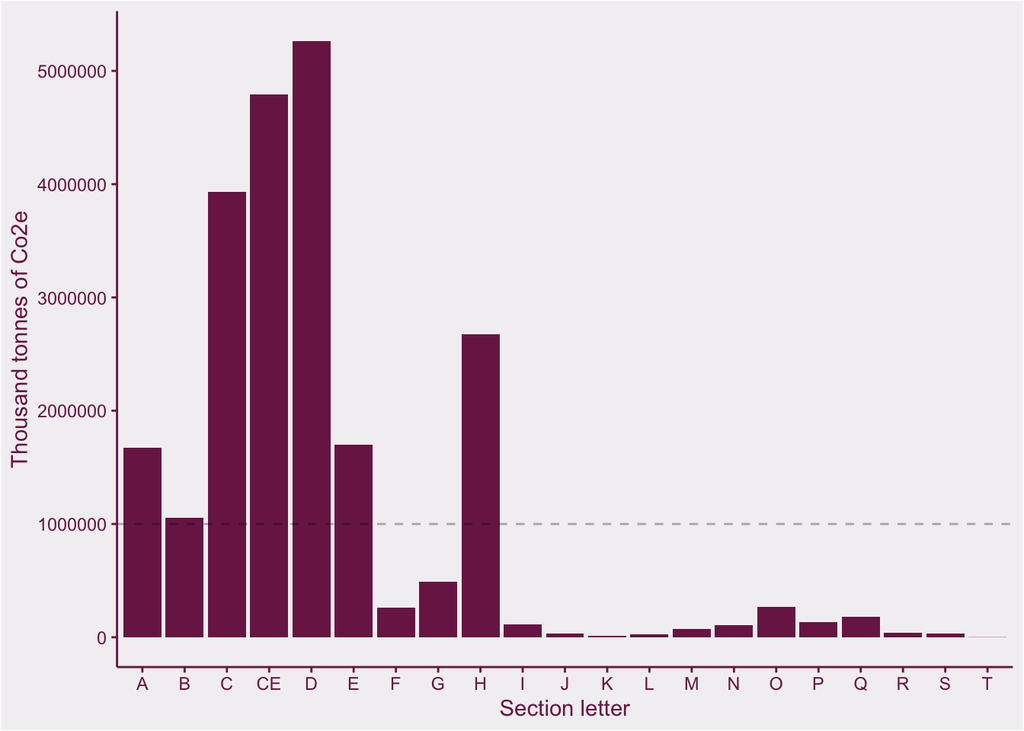

| Section letter | Section name | 2021 |
| --- | --- | --- |
| NA | Consumer expenditure | 134761.9 |
| D | Electricity, gas, steam and air conditioning supply | 86080.9 |
| C | Manufacturing | 81593.9 |
| H | Transport and storage | 56753.8 |
| A | Agriculture, forestry and fishing | 50040.0 |
| E | Water supply; sewerage, waste management and remediation activities | 26551.4 |
| B | Mining and quarrying | 17181.4 |
| G | Wholesale and retail trade; repair of motor vehicles and motorcycles | 14945.0 |

| Section letter | Section name | 1990 |
| --- | --- | --- |
| D | Electricity, gas, steam and air conditioning supply | 217638.6 |
| C | Manufacturing | 176067.9 |
| NA | Consumer expenditure | 143893.7 |
| E | Water supply; sewerage, waste management and remediation activities | 75232.5 |
| H | Transport and storage | 66667.4 |
| A | Agriculture, forestry and fishing | 55978.4 |
| B | Mining and quarrying | 50762.1 |
| O | Public administration and defence; compulsory social security | 12375.8 |

Industries reducing emissions the quickest and the slowest:

| Section name | pct_change |
| --- | --- |
| Construction | 76.202737 |
| Real estate activities | 40.083604 |
| Wholesale and retail trade; repair of motor vehicles and motorcycles | 23.237404 |
| Administrative and support service activities | 11.704375 |
| Accommodation and food services | 9.852829 |
| Consumer expenditure | -6.346213 |

| Section name | pct_change |
| --- | --- |
| Manufacturing | -53.65771 |
| Electricity, gas, steam and air conditioning supply | -60.44778 |
| Education | -63.57735 |
| Public administration and defence; compulsory social security | -64.11545 |
| Water supply; sewerage, waste management and remediation activities | -64.70754 |
| Mining and quarrying | -66.15309 |

### Sectors

Sectors contributing the most to emissions:

- Since 1991, 7 sectors have produced more than 1 million thousand tonnes of CO2e
- These 7 sectors were also the top emitters in 2021
- 5 feature in the top 7 emitters of 1990 with Manufacture of petrochemicals and Mining of coal and lignite rounding out the list in place of Electricity production - gas and Air transport services

| Section letter | Sector | 2021 |
| --- | --- | --- |
| NA | Consumer expenditure - not travel | 75897.8 |
| NA | Consumer expenditure - travel | 58864.2 |
| A | Products of agriculture, hunting and related services | 49204.5 |
| D | Electricity production - gas | 42516.1 |
| E | Waste collection, treatment and disposal services; materials recovery services | 22297.4 |
| D | Electricity production - coal | 20203.5 |
| H | Air transport services | 16871.2 |

| Section letter | Sector | 1990 |
| --- | --- | --- |
| D | Electricity production - coal | 188796.4 |
| NA | Consumer expenditure - not travel | 83410.2 |
| E | Waste collection, treatment and disposal services; materials recovery services | 71564.3 |
| NA | Consumer expenditure - travel | 60483.5 |
| A | Products of agriculture, hunting and related services | 54988.9 |
| C | Manufacture of petrochemicals | 42230.7 |
| B | Mining of coal and lignite | 25529.4 |

Industries reducing emissions the quickest and the slowest:

| Sector | absolute_change |
| --- | --- |
| Electricity production - gas | 40284.6 |
| Electricity production - other | 15986.3 |
| Specialised construction works | 2483.9 |
| Retail trade services, except of motor vehicles and motorcycles | 2437.0 |
| Taxis and other renting of private cars with driver | 1576.1 |
| Constructions and construction works for civil engineering | 1419.2 |

| Sector | absolute_change |
| --- | --- |
| Electricity production - oil | -13143.4 |
| Manufacture of basic Iron & Steel | -13787.7 |
| Mining of coal and lignite | -24816.8 |
| Manufacture of petrochemicals | -37482.2 |
| Waste collection, treatment and disposal services; materials recovery services | -49266.9 |
| Electricity production - coal | -168592.9 |

## How might emissions change over the next 5 years?

### Forecasting total emissions

Conducting a time series analysis using ARIMA * Autoregressive: using previous values to predict future values * Integrated: applying a transformation to make the mean of the time series stationary * Moving Average model: incorporating error terms for forecasting

Step 1: Plotting the time series to visualise overall trends in the data As we saw earlier, emissions are trending down, which indicates that the time series is not stationary.

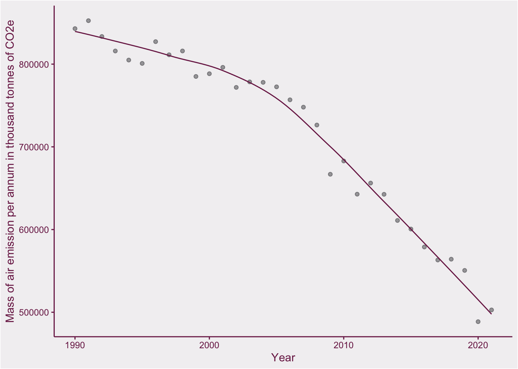

Step 2: Decompose the time series As there are no seasons in the data, there’s no need to decompose the data beyond what we’ve seen in the observed data and trend above.

Step 3: Autocorrelation and partial autocorrelation One of the assumptions when using an ARIMA model is that previous years have an influence on a future year. We investigate this by calculating autocorrelation: the correlation of a variable with itself at a different time. The autocorrelation plot indicates that for the next 7 time points, the value at time point x will have a strong influence.

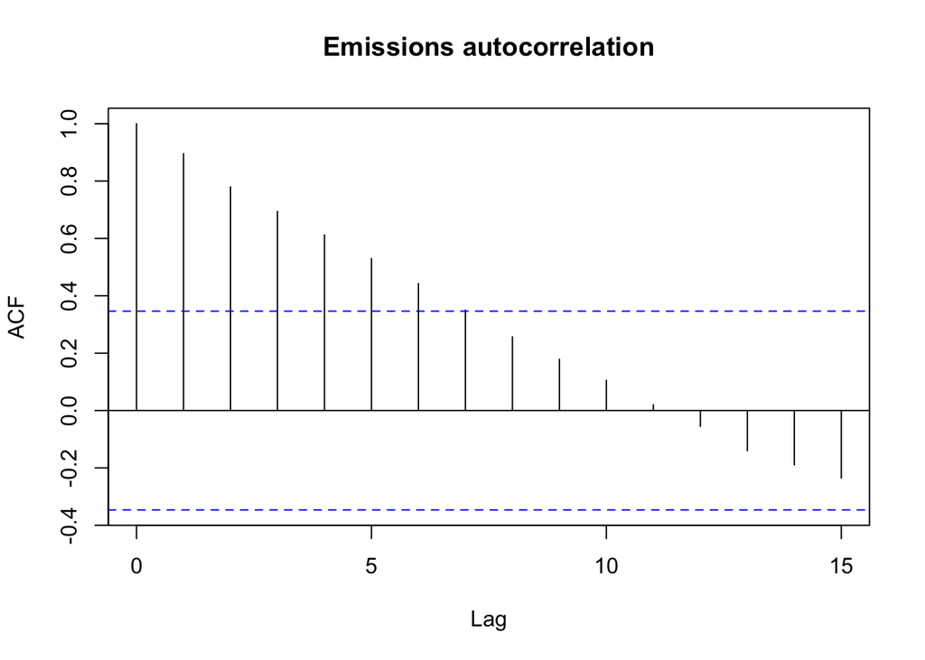

The partial autocorrelation plots tells us time point x does not have a strong influence beyond itself once we remove the effect of intervening time points. It also suggests that our model should have one autoregressive term.

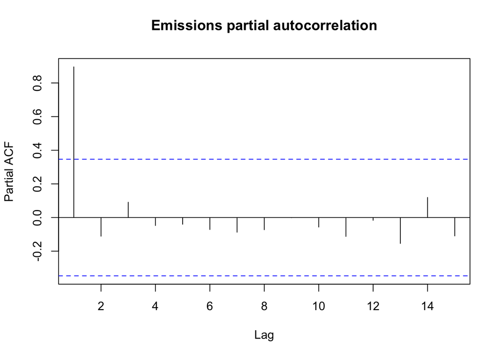

Step 4: Creating the model and forecasting

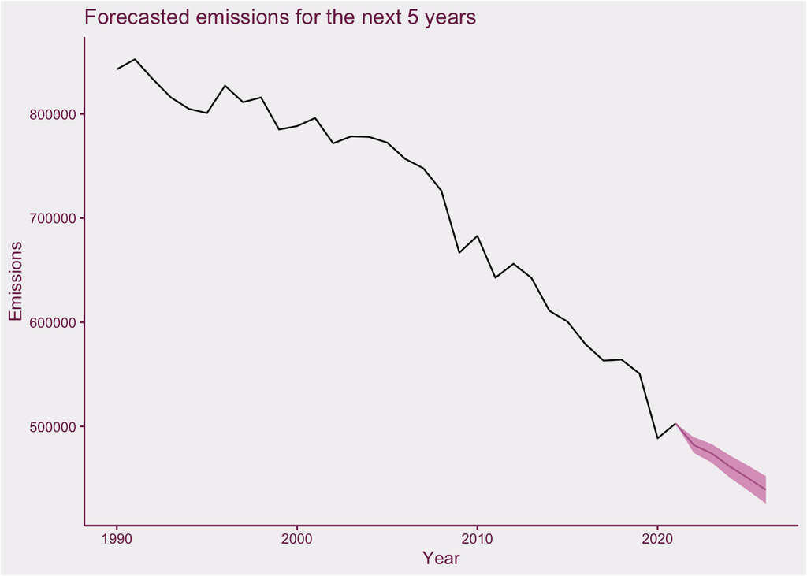

The model generated is a differenced first-order autoregressive model meaning that we have introduced a lag of one time period and differenced the time series once to make it stationary prior to modelling.

From the model, annual emissions are projected to continue declining in the UK with a reduction of close to 64000 thousand tonnes of CO2e between 2021 and 2026.

|  | Forecasted emissions | Lower forecast | Upper forecast |
| --- | --- | --- | --- |
| 2022 | 482133.6 | 474681.6 | 489585.7 |
| 2023 | 474130.0 | 465294.6 | 482965.4 |
| 2024 | 461534.2 | 451004.0 | 472064.4 |
| 2025 | 450605.5 | 438784.1 | 462426.9 |
| 2026 | 439071.6 | 426032.6 | 452110.6 |

Limitations:

- assumes that changes in policies and other factors, like technological advances, impacting GHG emissions come into effect at a similar rate and have a similar size impact on GHG emissions
- assumes that policies and other factors will continue to have the same directional effect on GHG emissions
- assumes that industries and sectors that have seen an increase in GHG emissions over the 31-year period will continue to have an increasing footprint
- the dataset is not dense
- cannot incorporate expected changes in policy based on past data

## What are the implications of this for the UK government?

### Climate Change Act 2008

Climate Change Act 2008 commits the government to reduce GHG emissions by at least 100% of 1990 levels by 2050. As part of this commitment, the government have also set intermediary targets called carbon budgets. Each carbon budget is a cap on the amount of GHG emitted over a 5-year period.

The model above covers the 2nd and 3rd carbon budgets.

#### 2nd carbon budget

The 2nd carbon budget came to an end in 2022 and demands a reduction of 38% on the 1990 baseline and a limit on CO2e of 2’544 million tonnes over the 5-year period starting 2018.

According to the model, we expect emissions in 2022 to have been 482’133 thousand tonnes of CO2e representing a reduction of 43% thus indicating that the UK is on target.

Cumulatively, in the 5-year period, the UK has emitted 2’588’245 thousand tonnes of C02e or 2’588 million tonnes of CO2e. Therefore, by this measure, the UK has failed to meet its 2nd budget goal and is off target.

### 3rd carbon budget

The 3rd carbon budget covers 2023-2027. It calls for a reduction of 52% on the 1990 baseline and a limit of 1’950 million tonnes of CO2e in the 5-year period.

The model estimates that the UK will emit 1’825 million tonnes of CO2e by 2026 meaning there is only 125 million tonnes of CO2e left in the 3rd carbon budget. Given that the the forecasted emissions in 2022-2026 are 3.5 times larger than the remainder of the budget, the UK is highly likely to miss this target.

Likewise, 2026 levels of emission are 48% lower than the 1990 baseline and the 2027 target is for emissions to be 52% lower so the UK will possibly miss that target too.